# Install Spark 1.4 for RStudio

Some instructions to install Spark 1.4 and SparkR for RStudio on a local Mac machine (running OS X Yosemite), using RStudio and the DataFrame functionality as a demo.

### Prerequisites:

- Ensure Java JDK v. 6 or greater is installed: http://www.oracle.com/technetwork/java/javase/downloads/jdk8-downloads-2133151.html
- Download Spark from the “Downloads” page: http://spark.apache.org/downloads.html
  - I used this package: Spark 1.4, Pre build for Hadoop 2.6 and later

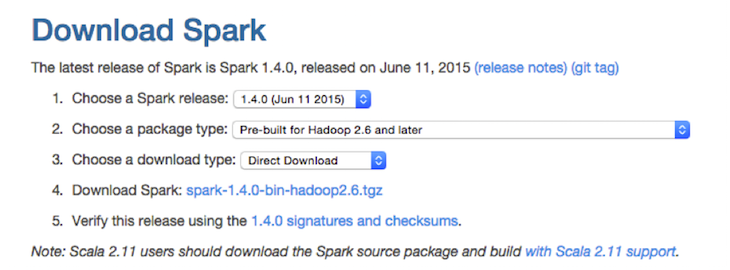

### Instructions:

- Unizp package to your desired location – in my case, for testing, I used the Downloads folder (anywhere you want to work with this package is fine)
- Open a terminal window and command line to the location of the Spark directory (.eg cd Downloads/spark-1.4.0-bin-hadoop2.6)

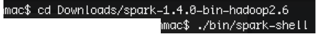

- Run ./bin/spark-shell the first time, to install dependencies and launch a local Spark instance

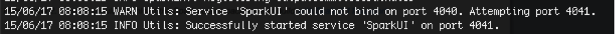

This should run and take you to a Scala prompt. We will close and launch another instance from RStudio, but doing this installed and launched the dependencies the first time I loaded up Spark. It will launch a localhost instance of Spark, accessible via localhost:4040, or 4041

### RStudio instructions:

- This section enables and allows for usage of the features built in to Spark, called SparkR: http://spark.apache.org/docs/latest/sparkr.html
- Switching to RStudio, open the dataframe.R sample code contained within this folder: */examples/src/main/r
- Add this code to the beginning of your script, per these instructions about using with RStudio: https://github.com/apache/spark/tree/master/R#using-sparkr-from-rstudio

```
#Set this line to where Spark is installed
Sys.setenv(SPARK_HOME="*/spark-1.4.0-bin-hadoop2.6")

# This line loads SparkR (the R package) from the installed directory

.libPaths(c(file.path(Sys.getenv("SPARK_HOME"), "R", "lib"), .libPaths()))

#load the SparkR package in RStudio
library(SparkR)

#initialize the Spark local cluster in R, as ‘sc’
sc <- sparkR.init(master="local")

#initialize the sqlContext piece for SparkR DataFrame functionality
sqlContext <- sparkRSQL.init(jsc = sc)
```

Follow the rest of the demo in dataframe.R to get a feel for how dataframes can be loaded into SparkR and utilized

```
# Create a simple local data.frame
localDF <- data.frame(name=c("John", "Smith", "Sarah"), age=c(19, 23, 18))

# Convert local data frame to a SparkR DataFrame
df <- createDataFrame(sqlContext, localDF)

# Print its schema
printSchema(df)

head(df)
# root
#  |-- name: string (nullable = true)
#  |-- age: double (nullable = true)

# Create a DataFrame from a JSON file
path <- file.path(Sys.getenv("SPARK_HOME"), "examples/src/main/resources/people.json")
peopleDF <- jsonFile(sqlContext, path)
printSchema(peopleDF)

head(peopleDF)

# Register this DataFrame as a table.
registerTempTable(peopleDF, "people")

# SQL statements can be run by using the sql methods provided by sqlContext
teenagers <- sql(sqlContext, "SELECT name FROM people WHERE age >= 13 AND age <= 19")

# Call collect to get a local data.frame
teenagersLocalDF <- collect(teenagers)

# Print the teenagers in our dataset
print(teenagersLocalDF)

# Stop the SparkContext now
sparkR.stop()
```

By navigating in your browser to localhost:4040 (or 4041, depending on the port), you can monitor jobs and ensure that calls you are making to the Spark host are actually working.

[figure not shown]